# Module2_Assignment_LDA

```r
activity %>%
  group_by(date) %>%
  summarize(total_steps_mean = mean(steps, na.rm = TRUE),
            total_steps_median = median(steps, na.rm = TRUE))
```

```
## # A tibble: 61 × 3
##    date       total_steps_mean total_steps_median
##    <date>                <dbl>              <dbl>
##  1 2012-10-01          NaN                     NA
##  2 2012-10-02            0.438                  0
##  3 2012-10-03           39.4                    0
##  4 2012-10-04           42.1                    0
##  5 2012-10-05           46.2                    0
##  6 2012-10-06           53.5                    0
##  7 2012-10-07           38.2                    0
##  8 2012-10-08          NaN                     NA
##  9 2012-10-09           44.5                    0
## 10 2012-10-10           34.4                    0
## # ℹ 51 more rows
```

# What is the average daily activity pattern?

## Make a time series plot (i.e. type = “l”) of the 5-minute interval (x-axis) and the average number of steps taken, averaged across all days (y-axis)

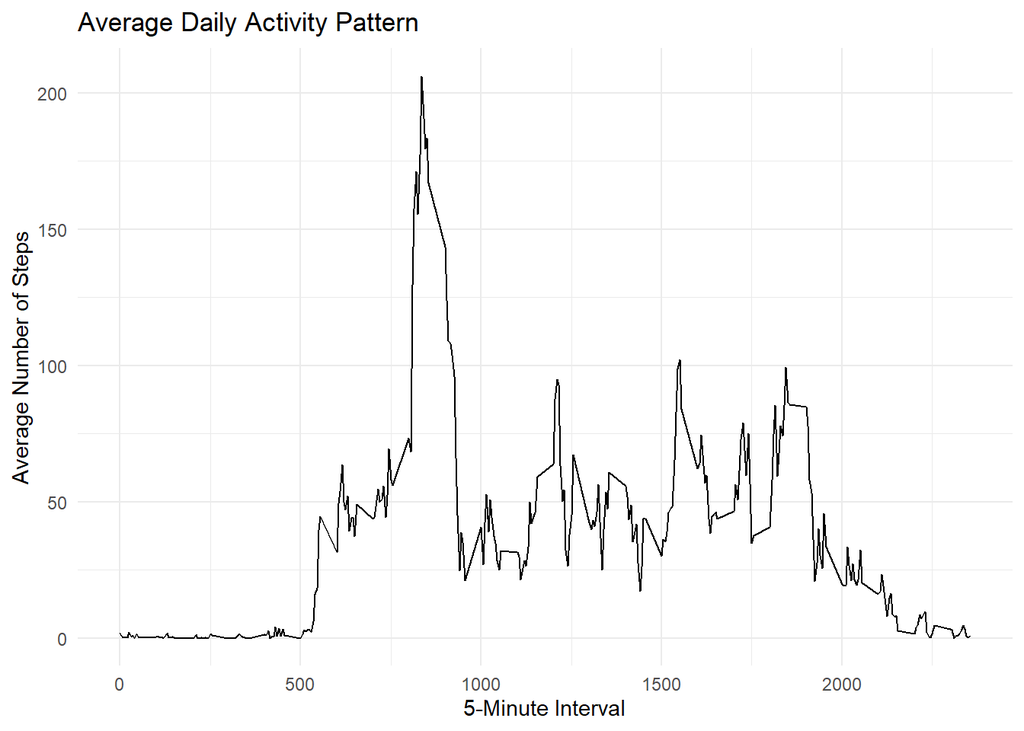

```r
activity_time_series <- activity %>%
  group_by(interval) %>%
  summarize(average_steps = mean(steps, na.rm = TRUE))

ggplot(activity_time_series, aes(x = interval, y = average_steps)) +
  geom_line() +
  labs(title = "Average Daily Activity Pattern",
       x = "5-Minute Interval",
       y = "Average Number of Steps") +
  theme_minimal()
```

## Which 5-minute interval, on average across all the days in the dataset, contains the maximum number of steps?

```r
activity_time_series %>%
  filter(average_steps == max(average_steps, na.rm = TRUE))
```

```
## # A tibble: 1 × 2
##   interval average_steps
##      <dbl>         <dbl>
## 1      835          206.
```

The answer is 835.

# Imputing missing values

## Calculate and report the total number of missing values in the dataset

```r
missing_rows <- activity %>% filter(is.na(steps))
nrow(missing_rows)
```

```
## [1] 2304
```

## Devise a strategy for filling in all of the missing values in the dataset. The strategy does not need to be sophisticated.

impute missing `steps`value with the **mean for that 5-minute interval**, averaged across all days.

```r
### Calculate the mean steps for each 5-minute interval (across all days)
interval_means <- activity %>%
  group_by(interval) %>%
  summarize(mean_steps = mean(steps, na.rm = TRUE))
```

### 3. Create New Dataset with Missing Data Filled In

```r
# Step 2: Join and impute missing values
activity_imputed <- activity %>%
  left_join(interval_means, by = "interval") %>%
  mutate(steps = ifelse(is.na(steps), mean_steps, steps)) %>%
  select(date, interval, steps)
```

### 4. Histogram of Total Steps per Day (After Imputation)

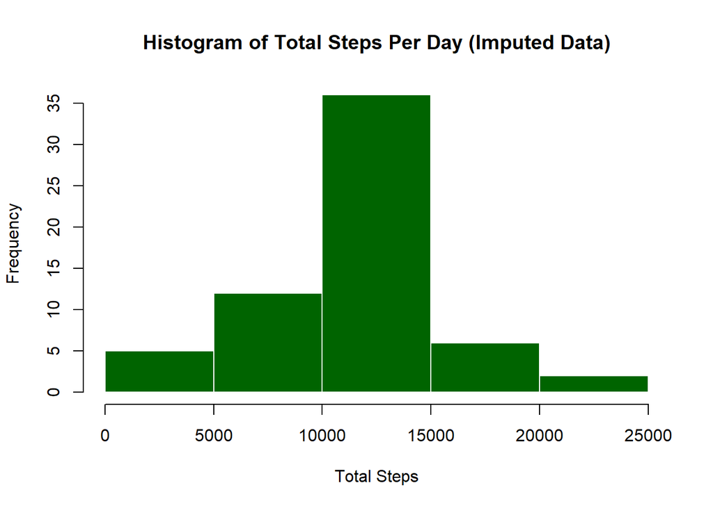

```r
# Summarize total steps per day
daily_steps_imputed <- activity_imputed %>%
  group_by(date) %>%
  summarize(total_steps = sum(steps))

# Plot histogram
hist(daily_steps_imputed$total_steps,
     main = "Histogram of Total Steps Per Day (Imputed Data)",
     xlab = "Total Steps",
     col = "darkgreen",
     border = "white")
```

### Mean and Median After Imputation

```r
mean_imputed <- mean(daily_steps_imputed$total_steps)
median_imputed <- median(daily_steps_imputed$total_steps)

mean_imputed
```

```
## [1] 10766.19
```

```r
median_imputed
```

```
## [1] 10766.19
```

### 🔍 Comparison and Impact

```r
# Original summary (without imputation)
daily_steps_original <- activity %>%
  group_by(date) %>%
  summarize(total_steps = sum(steps, na.rm = TRUE))

mean_original <- mean(daily_steps_original$total_steps, na.rm = TRUE)
median_original <- median(daily_steps_original$total_steps, na.rm = TRUE)

comparison <- data.frame(
  Version = c("Original", "Imputed"),
  Mean = c(mean_original, mean_imputed),
  Median = c(median_original, median_imputed)
)

comparison
```

```
##    Version     Mean   Median
## 1 Original  9354.23 10395.00
## 2  Imputed 10766.19 10766.19
```

### Interpretation

Before imputation: Some days have missing values, so sum(steps) for those days is lower or zero, which pulls the mean and median down.

After imputation: All missing steps values are filled using the mean for each interval. That means those days that were previously incomplete (or 0) now have a realistic total step count based on averages. This increases both the mean and the median because we’re no longer underestimating.